# 03_qc

Gulnara Tagridzhanova

18/01/2023

**Rationale:** before anything else, we need to QC all RNA-seq data and trim adapters

## Conclusions from Feb 13 2023:

Did a quick check and identified three problems with the data: untrimmed adapters, poly-T, and rRNA contamination. These shouldn’t matter if we do mapping to reference genome-transcriptome, but it would matter for de-novo transcriptome assembly. Two additional abnormalities are weird GC% and non-random first 10 bp, but these shouldn’t cause problems. Here I trimmed adapters and poly-Ts and removed rRNA for the libraries intended for de-novo assembly (i.e. thalli and pure cultures)

Below, see the step-by-step description of the analysis:

## 1. Proof of concept: QC and identifying problem

#### Ran FastQC on one pair of fastq files

```
source package /tsl/software/testing/bin/fastqc-0.11.5
mkdir analysis_and_temp_files/03_qc/fastqc_out -p
fastqc /tsl/data/reads/ntalbot/lichen_coculture_i_42_days/42xt_bmm2_ks/s_42xtb2/raw/S_42XTB2_*.fq.gz -o analysis_and_temp_files/03_qc/fastqc_out
```

- The results looked good, with three warnings:
  - Levels of Illumina Universal Adapter are elevated at the end of reads. This I will fix by trimmind
  - Non-random per base sequence content and kmer content (first 10 bp). This however [shouldn’t be a problem](https://www.bioinformatics.babraham.ac.uk/projects/fastqc/Help/3%20Analysis%20Modules/4%20Per%20Base%20Sequence%20Content.html)
  - FastQC also issued a warning about elevated read duplication levels, but this can be ignored, especially with RNA-Seq data

#### Trimmed reads with cutadapt

[output not shown]

- Ran FastQC again to confirm that adapter contamination is gone
- In a different library, (see below), got poly-T overrepresented sequences in the reverse reads. To fix it, change the cutadapt command

[output not shown]

- Ran FastQC again to confirm that poly-T contamination is gone

#### Investigated rRNA contamination

- Used SortMeRNA
- First, copied a SILVA database

```
cp /qib/platforms/Informatics/databases/silva/SILVA_132_QIIME_release/raw_data/initial_reads_SILVA132.fna.zip ./data
unzip ./data/initial_reads_SILVA132.fna.zip
```

- Compiled the database

```
source package /tgac/software/testing/bin/sortmerna-3.0.3
indexdb --ref initial_reads_SILVA132.fna,initial_reads_SILVA132.idx -v
```

- Tried running sortmerna-2.0: it can’t work with compressed files, but I had troubles getting sortmerna-3.0.3 to work (probably beceause I was trying to pass two read files, instead of one file with interleaved reads). This didn’t work, the rRNA file came empty. Probably, the issue is that I used the sortmerna-3.0.3 to complile the database index, and this version isn’t backward compatibile)

```
source package /tgac/software/testing/bin/sortmerna-2.0
mkdir analysis_and_temp_files/03_qc/sortmerna_tmp/S_42AB1

gzip -d analysis_and_temp_files/03_qc/trimmed_reads/S_42AB1_trimmed.*.fq.gz

#interleave reads. used earlier version sortmerna (just so happened, normally would use bbmap)
merge-paired-reads.sh analysis_and_temp_files/03_qc/trimmed_reads/S_42AB1_trimmed.1.fq analysis_and_temp_files/03_qc/trimmed_reads/S_42AB1_trimmed.2.fq analysis_and_temp_files/03_qc/trimmed_reads/S_42AB1_trimmed.merged.fq

gzip S_42AB1_trimmed.1.fq
gzip S_42AB1_trimmed.2.fq

sortmerna --ref data/initial_reads_SILVA132.fna,data/initial_reads_SILVA132.idx \
          --reads  analysis_and_temp_files/03_qc/trimmed_reads/S_42AB1_trimmed.merged.fq\
          --fastx --paired_in  \
          --aligned analysis_and_temp_files/03_qc/trimmed_reads/S_42AB1_trimmed.merged.rRNA --other  analysis_and_temp_files/03_qc/trimmed_reads/S_42AB1_trimmed.merged.non_rRNA -v -a 18
```

- Tried sortmerna-3.0.3 on a small subset (500 read pairs), to check if it works correctly. Seems to work fine. In the end, got 9 read pairs identified as rRNA

[output not shown]

- Sanity-check: what is the taxonomic identity of reads identified as rRNA? They blast to green algae, but not Asterochloris (Stichococcus, Protostichococcus, and such); plus, there’s a few bacterial hits. Will need to double-check the identity of the alga, but the method seems to be solid

```
cp -r ../../03_transcriptomic_analysis/code/fastq_species_detector/ .
# change the # of reads to subsample to 18
source package /tsl/software/testing/bin/blast+-2.9.0
bash fastq_species_detector/fastq_species_detector.sh S_42AB1_trimmed.merged_subset_rRNA.fastq /tsl/data/ncbi_database/blast/nt_20220819/
```

- Now do the same on one complete set of reads. Seems to work, but takes ages

[output not shown]

- Let’s replace the complete SILVA database (uncompressed fasta is ~3.7 Gb) with representative set (90% identity, as advised by [the sortmerna manual](https://bioinfo.lifl.fr/RNA/sortmerna/code/SortMeRNA-user-manual-v2.1.pdf), uncompressed fasta is ~60 Mb) downloaded from [the silva file archive](https://www.arb-silva.de/no_cache/download/archive/qiime/) (QIIME release 132)

```
source package /tgac/software/testing/bin/sortmerna-3.0.3
cd data/
indexdb --ref silva132_90.fna,silva132_90.idx -v
cd ..
```

- Now test it on the same small subset (500 read pairs). Results are similar. Surprisingly, now a few more reads are identified as rRNA (24 now vs 18 when I used the full silva database)

[output not shown]

- Amended the `code/sortmerna.sh` script to change the db, and ran it on one full library. Went much faster (was done overnight)

```
code/sortmerna.sh analysis_and_temp_files/03_qc/trimmed_reads/S_42AB1_trimmed.1.fq.gz analysis_and_temp_files/03_qc/trimmed_reads/S_42AB1_trimmed.2.fq.gz S_42AB1 analysis_and_temp_files/03_qc/trimmed_reads/S_42AB1_trimmed.bbmapmerged.non_rRNA.1.fq 22
```

## 2. Rarefaction analysis

- For the transcriptomes, I did a rarefaction analysis, to check whether the sequencing depth was sufficient
- Used bbmap to plot [“the fraction of unique reads produced by a sequencing run, as a function of the number of reads sequence”](https://jgi.doe.gov/data-and-tools/software-tools/bbtools/bb-tools-user-guide/calcuniqueness-guide/)
- For interpretation, the tool’s creator says [“In general, there is no reason to sequence further once”first” approaches zero in non-cumulative mode! … In some situations, like RNA-seq, single-cell, or metagenomes, in which the sequences have an exponential coverage distribution, you will NEVER reach zero.”](https://www.seqanswers.com/forum/bioinformatics/bioinformatics-aa/43538-how-to-plot-the-saturation-curves-to-assess-the-sequencing-depth)

```
source package /tsl/software/testing/bin/bbmap-37.90
bbcountunique.sh in=analysis_and_temp_files/03_qc/trimmed_reads/S_42AB1_trimmed.bbmapmerged.non_rRNA.1.fq.gz in2=analysis_and_temp_files/03_qc/trimmed_reads/S_42AB1_trimmed.bbmapmerged.non_rRNA.2.fq.gz out=analysis_and_temp_files/03_qc/rarefaction/rarefaction_S_42AB1.txt
```

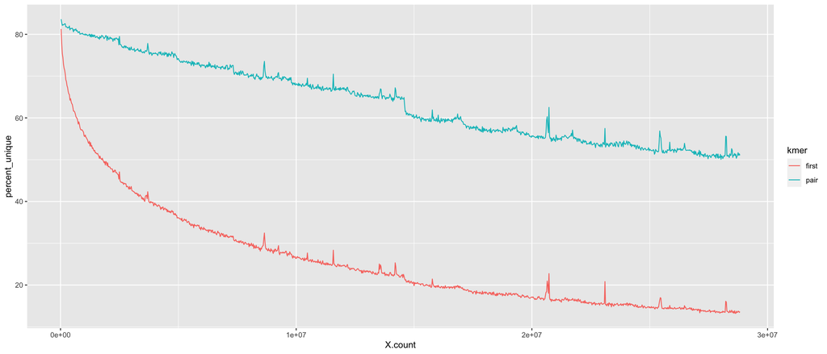

```r
library(tidyverse)
rare<-read.delim("../analysis_and_temp_files/03_qc/rarefaction/rarefaction_S_42AB1.txt")

rare<-rare %>% select(X.count,first,pair) %>% pivot_longer(-X.count,names_to = "kmer",values_to = "percent_unique")


ggplot(rare,aes(x=X.count,y=percent_unique,col=kmer))+geom_line()
```

## 3. Scaled this to the whole dataset

- Implemented as a snakemake pipeline `analysis/03_qc/Snakefile_qc`
- Did initial FastQC on all libraries
- Trimmed adapters on the libraries intended for de novo assemblies (libraries from pure cultures and lichen thalli). Did FastQC on the trimmed libraries
- Removed rRNA from these libraries

#### Results: Initial FastQC run

- Most files look normal, but there are several potential problems
- Abnormal GC%:
  - Libraries KS9HB1, KS9HB2, KS9HB3, KS48HB1, KS48HB2, KS48HB3, S_21HB3, S_42HB1,S_42HB3 (Chlorella), and S_21XHB1 (Xanthoria + Chlorella) have a small bump on the GC% plot around 50% (main peak is at 67%)
  - Libraries KS9XAB1, KS9XAB2, KS9XAB3 (Xanthoria + Asterochloris), KS9XHB3 (Xanthoria + Chlorella), KS48TCB1 (cladonia + trebouxia), KS48XHB1 (Xanthoria + Chlorella) have an asymmetric GC% peak
  - KS9XHB1, KS9XHB2, S_21XHB3, S_21XHW1, S_21XHW3, S_42XHW1 (Xanthoria + Chlorella) has a weird double-peak in GC%
- Overrepresented sequences
  - Many libraries have overrepresented poly-T sequence. Will have to remove them too
  - KS48NB1, KS48NB2, and KS48NB3 (trebouxia + aspergillus) have one overrepresented sequences with no hits `GGGATACCCGCTGAACTTAAGCATATCAATAAGCGGAGGAAAAGAAACCA`. The sequence blasts as rRNA. This will be taken care of by the rRNA-filtering step

#### Rarefaction analysis

- In all samples, percent unique falls below 25% by the end (min is 3%!)
- Given that this is metatranscriptomic data, it’s unlikely that we will get much better results even with deeper sequencing

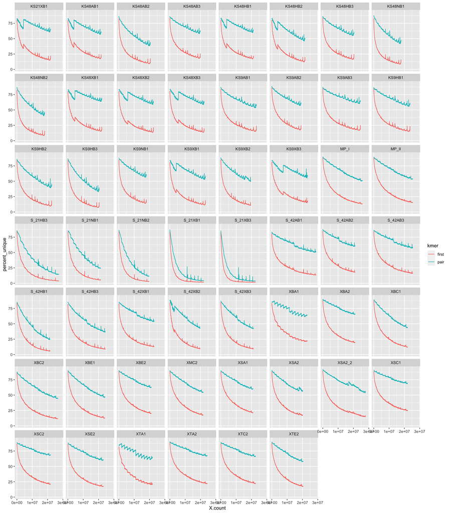

```r
library(stringr)
###define function
read_file<-function(x){
  rare<-read.delim(paste0("../analysis_and_temp_files/03_qc/rarefaction/",x))
  sample_id<-str_replace(x,"rarefaction_","") %>% str_replace(".txt","")
  rare<-rare %>% select(X.count,first,pair) %>% pivot_longer(-X.count,names_to = "kmer",values_to = "percent_unique")
  rare$sample<-sample_id
  return(rare)
}

###apply to all files
file_list<-list.files("../analysis_and_temp_files/03_qc/rarefaction/","rarefaction_")
l<-lapply(file_list,read_file)
rare_combine<-do.call(rbind,l)


ggplot(rare_combine,aes(x=X.count,y=percent_unique,col=kmer))+geom_line()+
  facet_wrap(.~sample,nrow=7)
```